# Final Exam Instructions

Advanced Regression (STAT 355-0)  
Winter 2025

Author

Zihan Chu

Published

March 21, 2025

**Github Repo Link**

To link to your github **repo**sitory, appropriately edit the example link below. Meaning replace `https://your-github-repo-url` with your github repo url. Suggest verifying the link works before submitting.

https://github.com/karliechu1023/myrepo.git

```r
library(readr)
library(readxl)
library(dplyr)
```

## An Overview of the Problem

Homelessness remains a critical issue across the United States, affecting hundreds of thousands of individuals each year. Despite numerous efforts to address the problem, recent data indicates that the number of homeless individuals has been increasing in several major metropolitan areas. Understanding the factors that contribute to homelessness is crucial for developing effective policies to mitigate this growing crisis.

## The Data

The data for this exam is sourced from the U.S. Department of Housing and Urban Development (HUD) and the U.S. Census Bureau, encompassing variables related to housing market conditions, economic factors, social safety nets, demographic characteristics, and climate data, all of which are critical in analyzing homelessness across various communities.

All of the information that you need to understand this data is provided in the `data/` sub-directory. This includes:

- `05b_analysis_file_update.csv` : The data
- `HUD TO3 - 05b Analysis File - Data Dictionary.xlsx` : The data dictionary

## This Exam

For this exam, we will focus in particular on one outcome:

- `homelessness_rate`[^1]: This represents the rate of homeless individuals as counted during the annual PIT survey. It is calculated by dividing the variable `pit_tot_hless_pit_hud` by `dem_pop_pop_census`, focusing exclusively on the **year 2017**.

<sup>1</sup> Not included in the data and must be calculated

**Note**

**A strong exam is one that is judicious in what is presented (you can put materials in an Appendix), that explains the decisions and assumptions that were made and why, that explains how the results should be interpreted, and that is clear in any limitations.**

Put another way, there is no single right answer to this analysis problem. There are many suitable approaches. Of course, there are approaches that are clearly not suitable too. The key is to concisely explain your work and provide evidence and/or sound reasoning for why your approach is appropriate. This includes identifying issues or limitations with your approach.

As George Box said, “All models are wrong, but some are useful.”

```r
homelessness_data <- read_csv("/Users/karlies/Desktop/05b_analysis_file_update.csv")
data_dictionary <- read_excel("/Users/karlies/Downloads/Data_Dictionary.xlsx")
```

## Questions

### Question 1

After exploring the outcome, what type of regression model might you use to for `homelessness_rate`? Explain your choice. If you considered more than one type, explain how you arrived at each and how you made your final decision.

**Solution**

```r
# create variable homelessness_rate
homelessness_data_2017 <- homelessness_data %>%
  filter(year == 2017) %>%
  mutate(homelessness_rate = pit_tot_hless_pit_hud / dem_pop_pop_census)
```

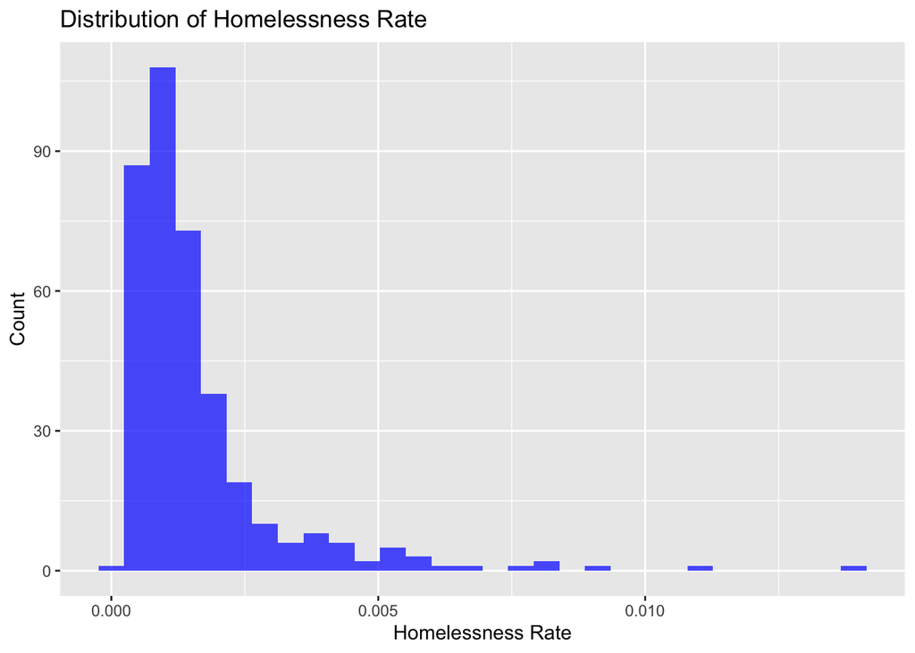

```r
# check the distribution of the variable
library(ggplot2)

ggplot(homelessness_data_2017, aes(x = homelessness_rate)) +
  geom_histogram(bins = 30, fill = "blue", alpha = 0.7) +
  labs(title = "Distribution of Homelessness Rate",
       x = "Homelessness Rate",
       y = "Count")
```

```r
summary(homelessness_data_2017$homelessness_rate)
```

```
     Min.   1st Qu.    Median      Mean   3rd Qu.      Max.      NA's
0.0002223 0.0007362 0.0011511 0.0015897 0.0017748 0.0141310         2
```

The histogram is highly right-skewed (positively skewed), bounded at zero (rates can’t be negative), Contains many observations near zero and has a few outliers at higher values. Given these characteristics, I recommend a gam model with log transformation model. The log transformation will help address the skewness in the data. The GAM approach would more accurately capture the complex relationships evident in your data, leading to better insights and predictive performance. This is particularly important when modeling social phenomena like homelessness that often have complex, non-linear relationships with their determinants.

### Question 2

The variable `homelessness_rate` represents the rate of homeless individuals per population unit. You hypothesize that the following variables may be associated with this outcome:

- `econ_labor_unemp_rate_BLS`: Unemployment rate
- `dem_soc_ed_hsgrad_acs5yr_2017`: Percentage of the population that are high school graduates in the population unit
- `econ_labor_medinc_acs5yr_2017`: Median income in the population unit
- `hou_mkt_medrent_acs5yr_2017`: Median rent in the population unit
- `env_wea_avgtemp_summer_noaa`: Average summer temperature (June, July, August)

Please perform an analysis to evaluate the relationship between these variables and the `homelessness_rate`. Be sure to interpret your findings and draw clear conclusions based on your analysis.

**Solution**

```r
library(dplyr)
library(mgcv)
homelessness_data_analysis <- homelessness_data_2017 %>%
  dplyr::select(homelessness_rate,
         econ_labor_unemp_rate_BLS,
         dem_soc_ed_hsgrad_acs5yr_2017,
         econ_labor_medinc_acs5yr_2017,
         hou_mkt_medrent_acs5yr_2017,
         env_wea_avgtemp_summer_noaa) %>%
  na.omit()

# Log-transform the homelessness rate
homelessness_data_analysis <- homelessness_data_analysis %>%
  mutate(log_homelessness_rate = log(homelessness_rate + 0.0001))

# Examine correlations between variables
correlation_matrix <- cor(homelessness_data_analysis, use = "complete.obs")
print(correlation_matrix)
```

```
                              homelessness_rate econ_labor_unemp_rate_BLS
homelessness_rate                   1.000000000                 0.1327462
econ_labor_unemp_rate_BLS           0.132746198                 1.0000000
dem_soc_ed_hsgrad_acs5yr_2017      -0.253189094                 0.2824742
econ_labor_medinc_acs5yr_2017       0.002705758                -0.3804004
hou_mkt_medrent_acs5yr_2017         0.302380525                -0.2562852
env_wea_avgtemp_summer_noaa        -0.139691835                 0.1586318
log_homelessness_rate               0.878562401                 0.1012712
                              dem_soc_ed_hsgrad_acs5yr_2017
homelessness_rate                                -0.2531891
econ_labor_unemp_rate_BLS                         0.2824742
dem_soc_ed_hsgrad_acs5yr_2017                     1.0000000
econ_labor_medinc_acs5yr_2017                    -0.6174576
hou_mkt_medrent_acs5yr_2017                      -0.6839425
env_wea_avgtemp_summer_noaa                       0.1297705
log_homelessness_rate                            -0.2765847
                              econ_labor_medinc_acs5yr_2017
homelessness_rate                               0.002705758
econ_labor_unemp_rate_BLS                      -0.380400436
dem_soc_ed_hsgrad_acs5yr_2017                  -0.617457617
econ_labor_medinc_acs5yr_2017                   1.000000000
hou_mkt_medrent_acs5yr_2017                     0.847322609
env_wea_avgtemp_summer_noaa                    -0.239474672
log_homelessness_rate                          -0.041844603
                              hou_mkt_medrent_acs5yr_2017
homelessness_rate                               0.3023805
econ_labor_unemp_rate_BLS                      -0.2562852
dem_soc_ed_hsgrad_acs5yr_2017                  -0.6839425
econ_labor_medinc_acs5yr_2017                   0.8473226
hou_mkt_medrent_acs5yr_2017                     1.0000000
env_wea_avgtemp_summer_noaa                    -0.1394450
log_homelessness_rate                           0.2798028
                              env_wea_avgtemp_summer_noaa log_homelessness_rate
homelessness_rate                              -0.1396918             0.8785624
econ_labor_unemp_rate_BLS                       0.1586318             0.1012712
dem_soc_ed_hsgrad_acs5yr_2017                   0.1297705            -0.2765847
econ_labor_medinc_acs5yr_2017                  -0.2394747            -0.0418446
hou_mkt_medrent_acs5yr_2017                    -0.1394450             0.2798028
env_wea_avgtemp_summer_noaa                     1.0000000            -0.1534553
log_homelessness_rate                          -0.1534553             1.0000000
```

```r
# Fit the gam model
gam_model <- gam(log_homelessness_rate ~
                s(econ_labor_unemp_rate_BLS) +
                s(dem_soc_ed_hsgrad_acs5yr_2017) +
                s(econ_labor_medinc_acs5yr_2017) +
                s(hou_mkt_medrent_acs5yr_2017) +
                s(env_wea_avgtemp_summer_noaa),
              data = homelessness_data_analysis,
              family = gaussian())

# Summarize the model
summary_result <- summary(gam_model)
print(summary_result)
```

```
Family: gaussian
Link function: identity

Formula:
log_homelessness_rate ~ s(econ_labor_unemp_rate_BLS) + s(dem_soc_ed_hsgrad_acs5yr_2017) +
    s(econ_labor_medinc_acs5yr_2017) + s(hou_mkt_medrent_acs5yr_2017) +
    s(env_wea_avgtemp_summer_noaa)

Parametric coefficients:
            Estimate Std. Error t value Pr(>|t|)
(Intercept) -6.63409    0.02478  -267.7   <2e-16 ***
---
Signif. codes:  0 '***' 0.001 '**' 0.01 '*' 0.05 '.' 0.1 ' ' 1

Approximate significance of smooth terms:
                                   edf Ref.df       F p-value
s(econ_labor_unemp_rate_BLS)     7.517  8.414   3.394 0.00108 **
s(dem_soc_ed_hsgrad_acs5yr_2017) 2.009  2.561   2.922 0.03535 *
s(econ_labor_medinc_acs5yr_2017) 1.000  1.000 205.294 < 2e-16 ***
s(hou_mkt_medrent_acs5yr_2017)   3.304  4.147  46.080 < 2e-16 ***
s(env_wea_avgtemp_summer_noaa)   1.000  1.000  45.129 < 2e-16 ***
---
Signif. codes:  0 '***' 0.001 '**' 0.01 '*' 0.05 '.' 0.1 ' ' 1

R-sq.(adj) =  0.478   Deviance explained = 49.9%
GCV = 0.23981  Scale est. = 0.22966   n = 374
```

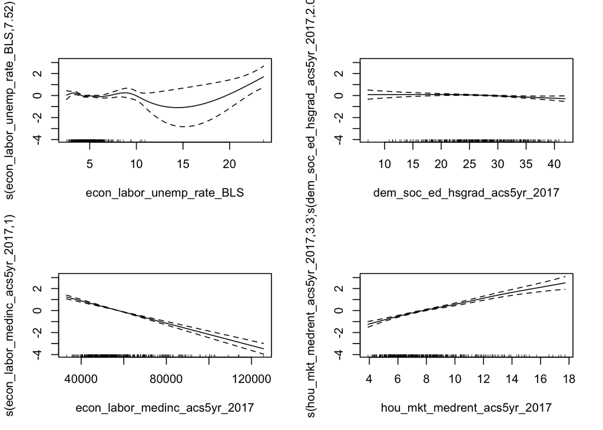

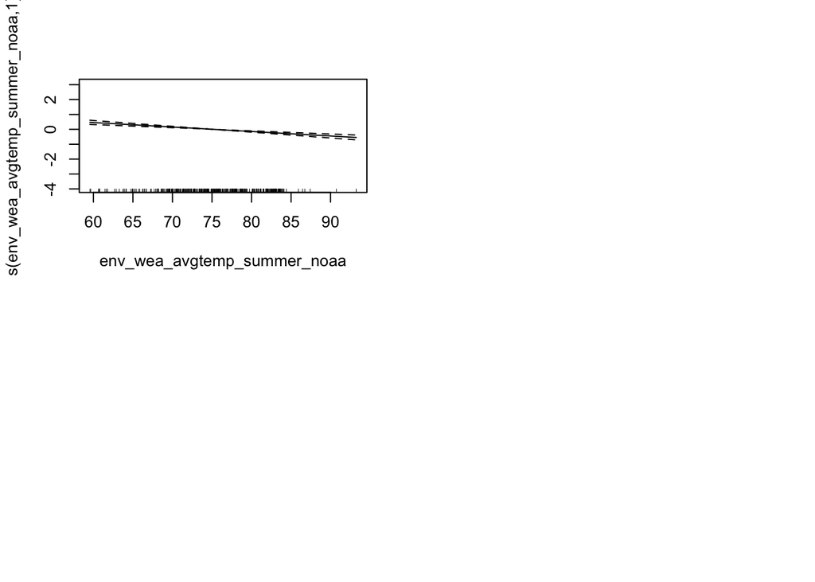

```r
par(mfrow = c(2, 2))
plot(gam_model)
```

### Question 3

Are there any non-linearities in these relationships explored in Question 2? Investigate and explain.

**Solution**

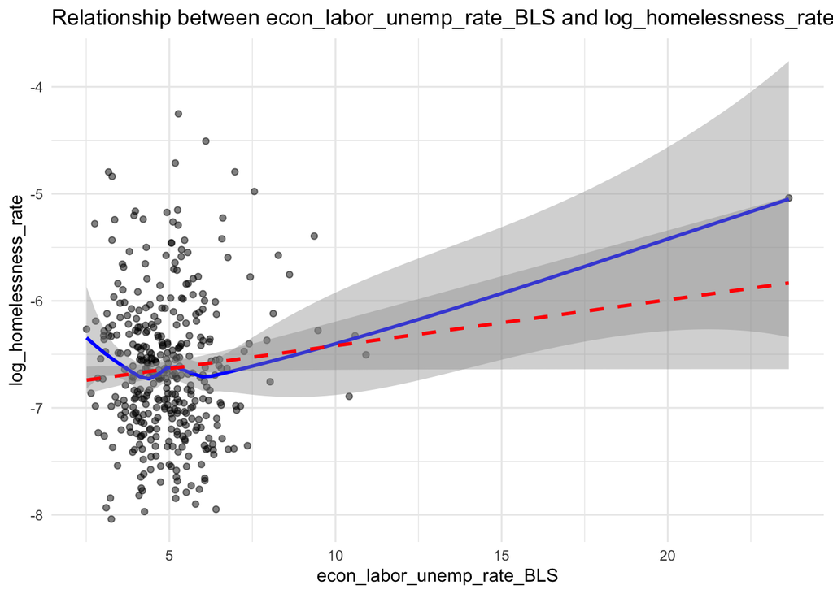

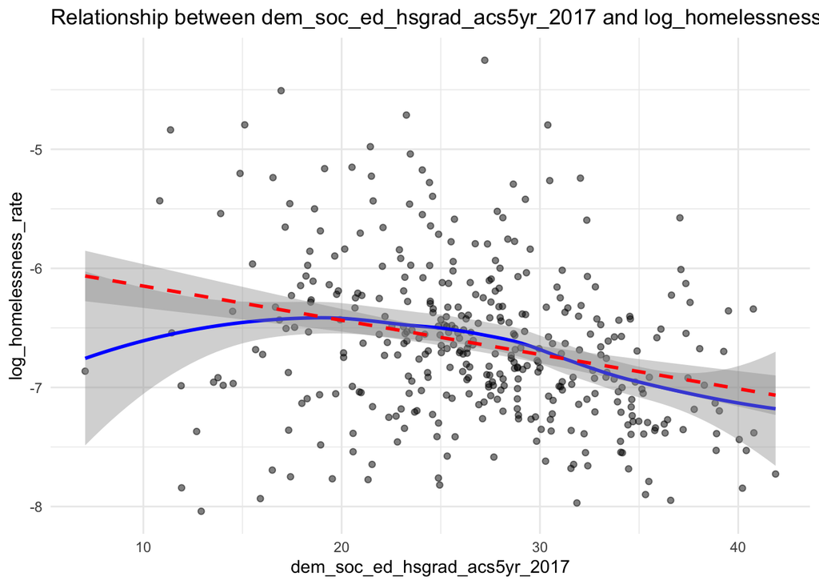

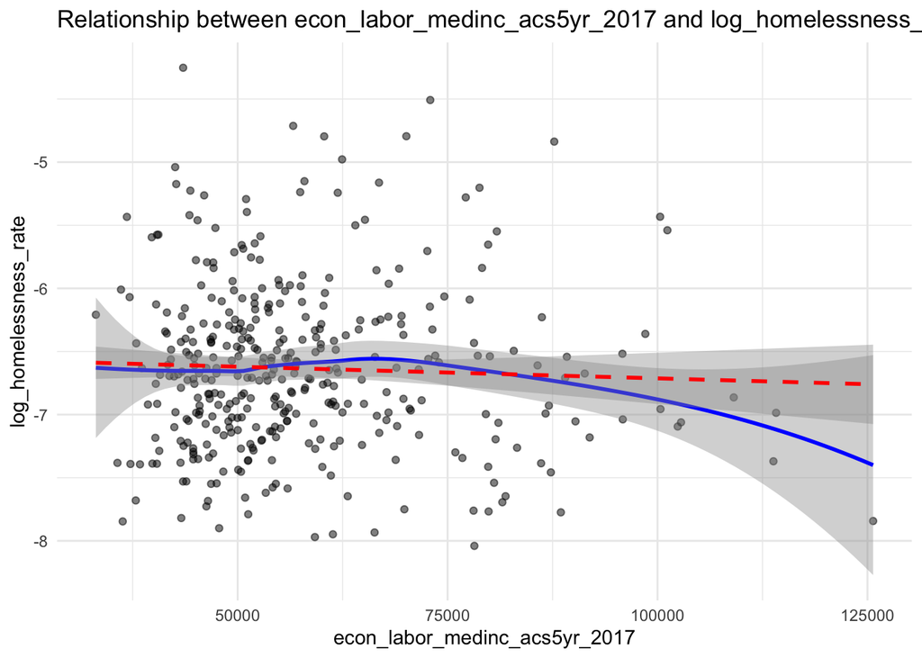

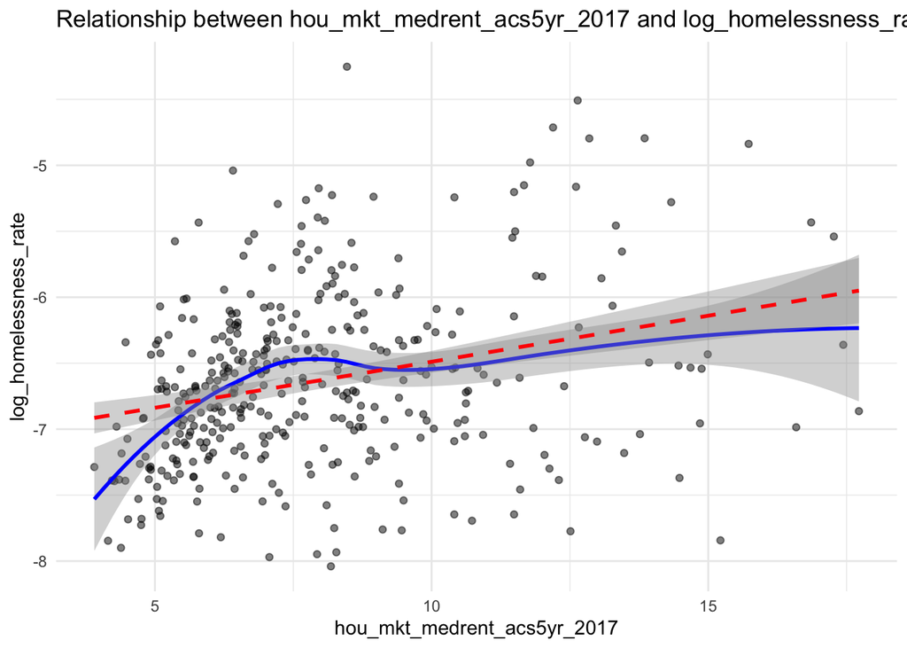

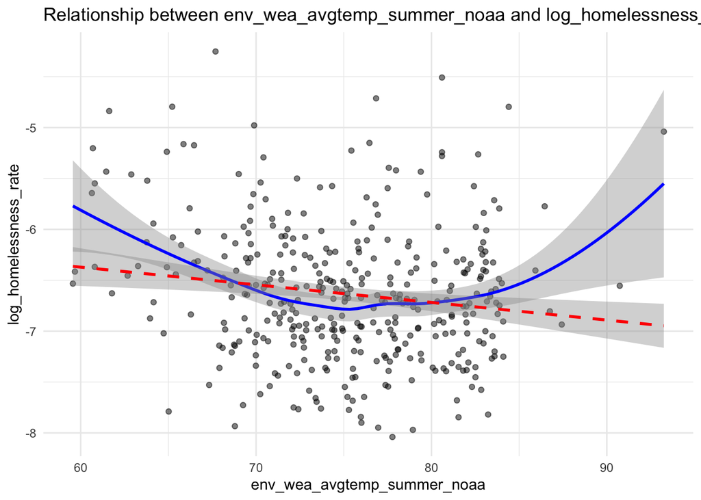

```r
plot_relationship <- function(data, x_var, y_var = "log_homelessness_rate") {
  ggplot(data, aes_string(x = x_var, y = y_var)) +
    geom_point(alpha = 0.5) +
    geom_smooth(method = "loess", color = "blue") +  # Non-linear smoothed line
    geom_smooth(method = "lm", color = "red", linetype = "dashed") +  # Linear reference
    theme_minimal() +
    labs(title = paste("Relationship between", x_var, "and", y_var),
         x = x_var, y = y_var)
}

# Generate plots for each predictor
predictors <- c("econ_labor_unemp_rate_BLS",
                "dem_soc_ed_hsgrad_acs5yr_2017",
                "econ_labor_medinc_acs5yr_2017",
                "hou_mkt_medrent_acs5yr_2017",
                "env_wea_avgtemp_summer_noaa")

for(predictor in predictors) {
  print(plot_relationship(homelessness_data_analysis, predictor))
}
```

```r
# Test for non-linearity using polynomial terms
poly_model <- lm(log_homelessness_rate ~
                  econ_labor_unemp_rate_BLS + I(econ_labor_unemp_rate_BLS^2) +
                  dem_soc_ed_hsgrad_acs5yr_2017 + I(dem_soc_ed_hsgrad_acs5yr_2017^2) +
                  econ_labor_medinc_acs5yr_2017 + I(econ_labor_medinc_acs5yr_2017^2) +
                  hou_mkt_medrent_acs5yr_2017 + I(hou_mkt_medrent_acs5yr_2017^2) +
                  env_wea_avgtemp_summer_noaa + I(env_wea_avgtemp_summer_noaa^2),
                data = homelessness_data_analysis)

summary(poly_model)
```

```
Call:
lm(formula = log_homelessness_rate ~ econ_labor_unemp_rate_BLS +
    I(econ_labor_unemp_rate_BLS^2) + dem_soc_ed_hsgrad_acs5yr_2017 +
    I(dem_soc_ed_hsgrad_acs5yr_2017^2) + econ_labor_medinc_acs5yr_2017 +
    I(econ_labor_medinc_acs5yr_2017^2) + hou_mkt_medrent_acs5yr_2017 +
    I(hou_mkt_medrent_acs5yr_2017^2) + env_wea_avgtemp_summer_noaa +
    I(env_wea_avgtemp_summer_noaa^2), data = homelessness_data_analysis)

Residuals:
     Min       1Q   Median       3Q      Max
-1.57778 -0.32986 -0.00962  0.29333  1.81508

Coefficients:
                                     Estimate Std. Error t value Pr(>|t|)
(Intercept)                        -9.959e-01  3.408e+00  -0.292 0.770313
econ_labor_unemp_rate_BLS          -1.407e-01  4.537e-02  -3.101 0.002080 **
I(econ_labor_unemp_rate_BLS^2)      8.086e-03  2.191e-03   3.691 0.000258 ***
dem_soc_ed_hsgrad_acs5yr_2017       3.655e-02  3.185e-02   1.148 0.251871
I(dem_soc_ed_hsgrad_acs5yr_2017^2) -9.777e-04  5.830e-04  -1.677 0.094412 .
econ_labor_medinc_acs5yr_2017      -6.710e-05  1.458e-05  -4.602 5.78e-06 ***
I(econ_labor_medinc_acs5yr_2017^2)  1.231e-10  1.013e-10   1.215 0.225217
hou_mkt_medrent_acs5yr_2017         3.709e-01  7.653e-02   4.846 1.87e-06 ***
I(hou_mkt_medrent_acs5yr_2017^2)   -5.190e-03  3.828e-03  -1.356 0.175996
env_wea_avgtemp_summer_noaa        -8.951e-02  9.215e-02  -0.971 0.331991
I(env_wea_avgtemp_summer_noaa^2)    3.828e-04  6.211e-04   0.616 0.538036
---
Signif. codes:  0 '***' 0.001 '**' 0.01 '*' 0.05 '.' 0.1 ' ' 1

Residual standard error: 0.4869 on 363 degrees of freedom
Multiple R-squared:  0.4758,    Adjusted R-squared:  0.4614
F-statistic: 32.95 on 10 and 363 DF,  p-value: < 2.2e-16
```

```r
# Compare linear and polynomial models
anova(gam_model, poly_model)
```

```
Family: gaussian
Link function: identity

Formula:
log_homelessness_rate ~ s(econ_labor_unemp_rate_BLS) + s(dem_soc_ed_hsgrad_acs5yr_2017) +
    s(econ_labor_medinc_acs5yr_2017) + s(hou_mkt_medrent_acs5yr_2017) +
    s(env_wea_avgtemp_summer_noaa)

Approximate significance of smooth terms:
                                   edf Ref.df       F p-value
s(econ_labor_unemp_rate_BLS)     7.517  8.414   3.394 0.00108
s(dem_soc_ed_hsgrad_acs5yr_2017) 2.009  2.561   2.922 0.03535
s(econ_labor_medinc_acs5yr_2017) 1.000  1.000 205.294 < 2e-16
s(hou_mkt_medrent_acs5yr_2017)   3.304  4.147  46.080 < 2e-16
s(env_wea_avgtemp_summer_noaa)   1.000  1.000  45.129 < 2e-16
```

There are clear non-linear relationships between several predictor variables and the homelessness rate.

These polynomial regression findings align with the GAM results, which also identified strong non-linearity in the unemployment relationship and more modest non-linearity in education. The polynomial approach offers the additional benefit of quantifying these relationships in ways that can be directly incorporated into predictive models.

### Question 4

How do these effects vary between rural and non-rural areas (suburban and major cities)? Use the variable `rural` (an indicator of rural areas) to explore these differences. Interpret your findings and discuss any significant variations you observe.

**Solution**

```r
homelessness_data_analysis2 <- homelessness_data_2017 %>%
  mutate(homelessness_rate = pit_tot_hless_pit_hud / dem_pop_pop_census,
         log_homelessness_rate = log(homelessness_rate + 0.0001),
         rural = as.factor(rural)
  )%>%
  dplyr::select(homelessness_rate, log_homelessness_rate, rural,
         econ_labor_unemp_rate_BLS,
         dem_soc_ed_hsgrad_acs5yr_2017,
         econ_labor_medinc_acs5yr_2017,
         hou_mkt_medrent_acs5yr_2017,
         env_wea_avgtemp_summer_noaa) %>%
  na.omit()
str(homelessness_data_analysis2)
```

```
tibble [374 × 8] (S3: tbl_df/tbl/data.frame)
 $ homelessness_rate            : num [1:374] 0.003793 0.001614 0.00114 0.000974 0.000584 ...
 $ log_homelessness_rate        : num [1:374] -5.55 -6.37 -6.69 -6.84 -7.29 ...
 $ rural                        : Factor w/ 2 levels "0","1": 1 2 1 1 2 1 1 2 1 2 ...
 $ econ_labor_unemp_rate_BLS    : num [1:374] 5.56 7.94 5.36 6.22 6.59 ...
 $ dem_soc_ed_hsgrad_acs5yr_2017: num [1:374] 24.1 31.3 24.4 30 34.7 ...
 $ econ_labor_medinc_acs5yr_2017: num [1:374] 80862 69735 53369 46631 40663 ...
 $ hou_mkt_medrent_acs5yr_2017  : num [1:374] 11.46 9.48 6.44 6.41 3.9 ...
 $ env_wea_avgtemp_summer_noaa  : num [1:374] 60.8 60.8 80.9 81.9 79.4 ...
 - attr(*, "na.action")= 'omit' Named int [1:2] 14 252
  ..- attr(*, "names")= chr [1:2] "14" "252"
```

```r
homelessness_data_2017 %>%
  group_by(rural) %>%
  summarize(
    mean_homelessness_rate = mean(homelessness_rate, na.rm = TRUE),
    median_homelessness_rate = median(homelessness_rate, na.rm = TRUE),
    count = n()
  )
```

```
# A tibble: 2 × 4
  rural mean_homelessness_rate median_homelessness_rate count
  <dbl>                  <dbl>                    <dbl> <int>
1     0                0.00165                 0.00125    264
2     1                0.00145                 0.000823   112
```

```r
rural_model <- gam(log_homelessness_rate ~
                s(econ_labor_unemp_rate_BLS) +
                s(dem_soc_ed_hsgrad_acs5yr_2017) +
                s(econ_labor_medinc_acs5yr_2017) +
                s(hou_mkt_medrent_acs5yr_2017) +
                s(env_wea_avgtemp_summer_noaa),
              data = subset(homelessness_data_analysis2, rural == 1),
              method = "REML")


nonrural_model <- gam(log_homelessness_rate ~
                   s(econ_labor_unemp_rate_BLS) +
                   s(dem_soc_ed_hsgrad_acs5yr_2017) +
                   s(econ_labor_medinc_acs5yr_2017) +
                   s(hou_mkt_medrent_acs5yr_2017) +
                   s(env_wea_avgtemp_summer_noaa),
                 data = subset(homelessness_data_analysis2, rural == 0),
                 method = "REML")

# Compare model results
summary(rural_model)
```

```
Family: gaussian
Link function: identity

Formula:
log_homelessness_rate ~ s(econ_labor_unemp_rate_BLS) + s(dem_soc_ed_hsgrad_acs5yr_2017) +
    s(econ_labor_medinc_acs5yr_2017) + s(hou_mkt_medrent_acs5yr_2017) +
    s(env_wea_avgtemp_summer_noaa)

Parametric coefficients:
            Estimate Std. Error t value Pr(>|t|)
(Intercept) -6.79563    0.03995  -170.1   <2e-16 ***
---
Signif. codes:  0 '***' 0.001 '**' 0.01 '*' 0.05 '.' 0.1 ' ' 1

Approximate significance of smooth terms:
                                   edf Ref.df       F  p-value
s(econ_labor_unemp_rate_BLS)     1.000   1.00   1.065 0.304510
s(dem_soc_ed_hsgrad_acs5yr_2017) 4.464   5.52   3.142 0.009504 **
s(econ_labor_medinc_acs5yr_2017) 1.000   1.00  58.048  < 2e-16 ***
s(hou_mkt_medrent_acs5yr_2017)   1.000   1.00 124.737  < 2e-16 ***
s(env_wea_avgtemp_summer_noaa)   1.000   1.00  13.421 0.000399 ***
---
Signif. codes:  0 '***' 0.001 '**' 0.01 '*' 0.05 '.' 0.1 ' ' 1

R-sq.(adj) =  0.662   Deviance explained = 68.8%
-REML = 74.406  Scale est. = 0.1756    n = 110
```

```r
summary(nonrural_model)
```

```
Family: gaussian
Link function: identity

Formula:
log_homelessness_rate ~ s(econ_labor_unemp_rate_BLS) + s(dem_soc_ed_hsgrad_acs5yr_2017) +
    s(econ_labor_medinc_acs5yr_2017) + s(hou_mkt_medrent_acs5yr_2017) +
    s(env_wea_avgtemp_summer_noaa)

Parametric coefficients:
            Estimate Std. Error t value Pr(>|t|)
(Intercept) -6.56678    0.02985    -220   <2e-16 ***
---
Signif. codes:  0 '***' 0.001 '**' 0.01 '*' 0.05 '.' 0.1 ' ' 1

Approximate significance of smooth terms:
                                   edf Ref.df       F  p-value
s(econ_labor_unemp_rate_BLS)     2.656  3.224   4.356  0.00421 **
s(dem_soc_ed_hsgrad_acs5yr_2017) 1.000  1.000   3.488  0.06295 .
s(econ_labor_medinc_acs5yr_2017) 1.000  1.000 138.281  < 2e-16 ***
s(hou_mkt_medrent_acs5yr_2017)   1.000  1.000  99.054  < 2e-16 ***
s(env_wea_avgtemp_summer_noaa)   1.067  1.130  27.321 4.28e-07 ***
---
Signif. codes:  0 '***' 0.001 '**' 0.01 '*' 0.05 '.' 0.1 ' ' 1

R-sq.(adj) =  0.402   Deviance explained = 41.7%
-REML = 196.78  Scale est. = 0.23522   n = 264
```

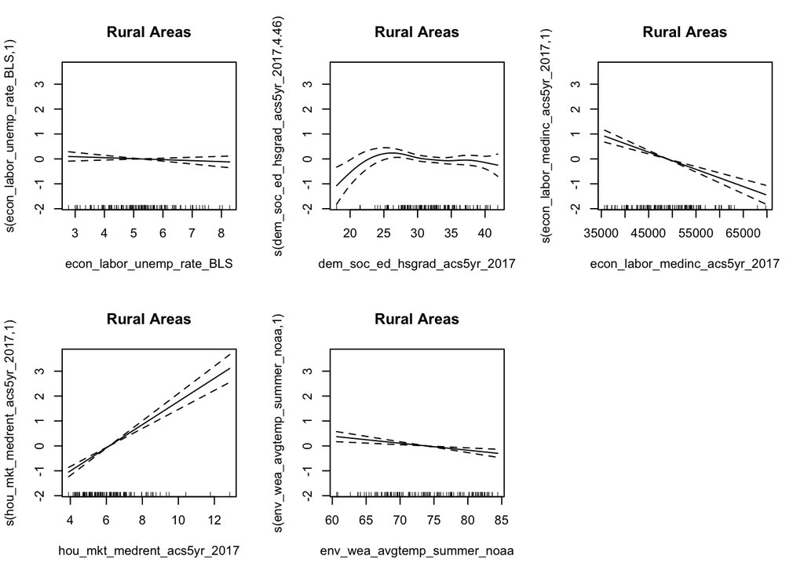

```r
par(mfrow=c(2,3))
plot(rural_model, pages=1, main="Rural Areas")
```

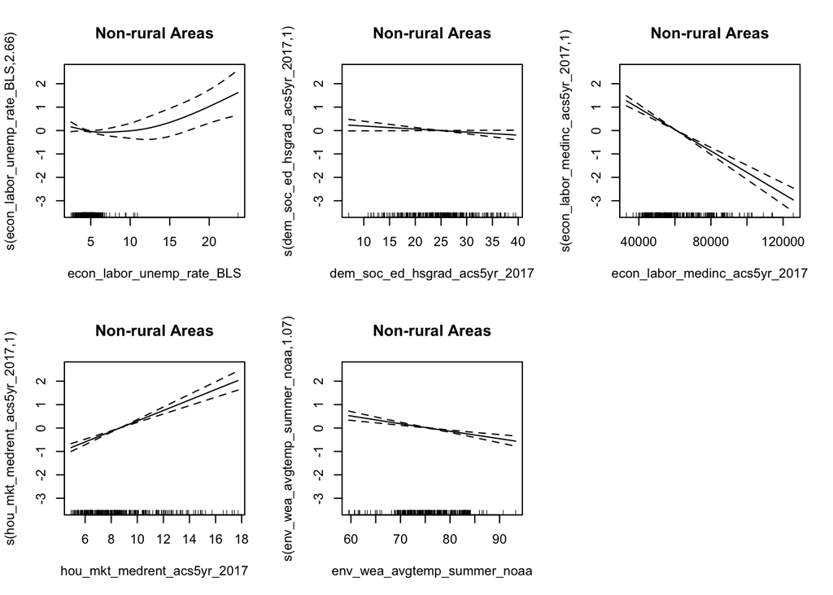

```r
par(mfrow=c(2,3))
plot(nonrural_model, pages=1, main="Non-rural Areas")
```

```r
rural_performance <- summary(rural_model)
nonrural_performance <- summary(nonrural_model)

model_comparison <- data.frame(
  Model = c("Rural GAM", "Non-rural GAM"),
  Deviance_Explained = c(rural_performance$dev.expl, nonrural_performance$dev.expl),
  R_Squared = c(rural_performance$r.sq, nonrural_performance$r.sq),
  AIC = c(AIC(rural_model), AIC(nonrural_model))
)

print(model_comparison)
```

```
          Model Deviance_Explained R_Squared      AIC
1     Rural GAM          0.6884678 0.6622390 133.5567
2 Non-rural GAM          0.4171350 0.4018452 378.0035
```

The GAM analysis reveals substantial differences in how socioeconomic factors influence homelessness rates across rural and non-rural settings. The rural model demonstrates considerably stronger explanatory power and shows distinctive patterns in how certain factors affect homelessness.

1. Unemployment Rate: Rural areas is not statistically significant (p=0.304510) with a linear relationship (edf=1.000). Non-rural areas has significant non-linear relationship (p=0.00421) with moderate complexity (edf=2.656). The smooth plots illustrate this contrast clearly. In rural areas, unemployment shows a weak, slightly negative linear association with homelessness rates. In non-rural areas, however, unemployment exhibits a U-shaped relationship, where homelessness rates increase more rapidly at higher unemployment levels.
2. Education (dem_soc_ed_hsgrad_acs5yr_2017): Rural areas has significant non-linear relationship (p=0.009504) with substantial complexity (edf=4.464). Non-rural areas has marginally significant linear relationship (p=0.06295, edf=1.000). This represents a complete reversal of pattern. In rural areas, education shows a complex relationship with homelessness, featuring an inverted U-shape peaking around 25-30% graduation rates. In non-rural areas, education shows a simpler negative linear association.
3. Median Income: Rural areas has strong linear negative relationship (p<2e-16, F=58.048). Non-rural areas has strong linear negative relationship (p<2e-16, F=138.281). Both settings show consistent negative relationships between income and homelessness, but the effect appears stronger in non-rural areas as indicated by the higher F-statistic.
4. Median Rent: Rural areas has strong positive linear relationship (p<2e-16, F=124.737). Non-rural areas has strong positive linear relationship (p<2e-16, F=99.054). Housing costs show consistently positive relationships with homelessness in both settings, but the effect appears somewhat stronger in rural areas based on the F-statistic.
5. Summer Temperature: Rural areas has significant linear negative relationship (p=0.000399). Non-rural areas has significant near-linear relationship (p=4.28e-07, edf=1.067). Temperature effects are similar across settings, with warmer areas generally showing lower homelessness rates.

### Question 5

Examining the data[^2], there are many other possible variables that could be used to model homelessness rates (`homelessness_rate`) than those hypothesized in #2. Develop a strategy and implement it to develop the best model for predicting homelessness rates. How well does this model predict homelessness rates? How much better (or worse) at predicting homelessness rates is it than the model developed in #2?

<sup>2</sup> Only consider data from the year 2017.

**Solution**

```r
library(dplyr)
library(ggplot2)
library(caret)
library(MASS)
library(glmnet)
```

```r
homeless_data_Q5 <- homelessness_data %>%
  filter(year == 2017) %>%
  mutate(homelessness_rate = pit_tot_hless_pit_hud / dem_pop_pop_census,
         log_homelessness_rate = log(homelessness_rate + 0.0001))
```

```r
# select the usable predictors which has missing value < 5
var_missing <- colSums(is.na(homeless_data_Q5)) / nrow(homeless_data_Q5) * 100
print(sort(var_missing[var_missing > 0], decreasing = TRUE)[1:20])
```

```
             dem_age_boom_census     dem_health_alcoholdeath_IMHE
                     100.0000000                      100.0000000
           dem_mort_lifeexp_IMHE       dem_health_ins_acs5yr_2012
                     100.0000000                      100.0000000
            hou_pol_fund_project        d_pit_hless_pit_hud_share
                       1.0638298                        0.7978723
       d_pit_shelt_pit_hud_share      d_pit_unshelt_pit_hud_share
                       0.7978723                        0.7978723
           pit_tot_shelt_pit_hud          pit_tot_unshelt_pit_hud
                       0.5319149                        0.5319149
           pit_tot_hless_pit_hud            pit_ind_shelt_pit_hud
                       0.5319149                        0.5319149
         pit_ind_unshelt_pit_hud            pit_ind_hless_pit_hud
                       0.5319149                        0.5319149
        pit_perfam_shelt_pit_hud       pit_perfam_unshelt_pit_hud
                       0.5319149                        0.5319149
        pit_perfam_hless_pit_hud    pit_ind_chronic_hless_pit_hud
                       0.5319149                        0.5319149
pit_perfam_chronic_hless_pit_hud            pit_vet_hless_pit_hud
                       0.5319149                        0.5319149
```

```r
low_missing_vars <- names(var_missing[var_missing < 5])
low_missing_vars <- low_missing_vars[!low_missing_vars %in% c("homelessness_rate", "log_homelessness_rate")]
low_missing_vars <- low_missing_vars[sapply(homeless_data_Q5[low_missing_vars], is.numeric)]
```

```r
# 4. Examine correlations with homelessness_rate
correlations <- data.frame(
  variable = low_missing_vars,
  correlation = sapply(low_missing_vars, function(var) {
    cor(homeless_data_Q5[[var]], homeless_data_Q5$homelessness_rate,
        use = "pairwise.complete.obs")
  })
)
correlations <- correlations[order(abs(correlations$correlation), decreasing = TRUE), ]
print(head(correlations, 10))  # Top 10 correlated variables
```

```
                                                   variable correlation
pit_hless_pit_hud_share             pit_hless_pit_hud_share   1.0000000
pit_unshelt_pit_hud_share         pit_unshelt_pit_hud_share   0.8261838
pit_shelt_pit_hud_share             pit_shelt_pit_hud_share   0.7156047
hou_mkt_rentshare_acs5yr_2012 hou_mkt_rentshare_acs5yr_2012   0.4980660
hou_mkt_rentshare_acs5yr           hou_mkt_rentshare_acs5yr   0.4770834
hou_mkt_rentshare_acs5yr_2017 hou_mkt_rentshare_acs5yr_2017   0.4770834
hou_mkt_rentshare_xt                   hou_mkt_rentshare_xt   0.4770834
sub_west_coast                               sub_west_coast   0.4700787
sub_high_rent_share75                 sub_high_rent_share75   0.4424375
sub_west_census                             sub_west_census   0.4421012
```

```r
# 5. Create training and testing datasets
set.seed(123)
homeless_data_complete <- na.omit(homeless_data_Q5[, c("log_homelessness_rate", low_missing_vars)])
train_indices <- sample(1:nrow(homeless_data_complete), 0.7 * nrow(homeless_data_complete))
train_data <- homeless_data_complete[train_indices, ]
test_data <- homeless_data_complete[-train_indices, ]
```

```r
# 6. Fit original model from Question 2
original_model <- gam(log_homelessness_rate ~
                   s(econ_labor_unemp_rate_BLS) +
                   s(dem_soc_ed_hsgrad_acs5yr_2017) +
                   s(econ_labor_medinc_acs5yr_2017) +
                   s(hou_mkt_medrent_acs5yr_2017) +
                   s(env_wea_avgtemp_summer_noaa),
                  family = gaussian(),
                  method = "REML",
                  data = train_data)
```

```r
# 7. Correlation-based model (using top correlated variables)
top_vars <- head(correlations, 10)$variable
correlation_formula <- paste("log_homelessness_rate ~", paste(top_vars, collapse = " + "))
correlation_model <- gam(as.formula(correlation_formula),
                   family = gaussian(),
                   method = "REML",
                   data = train_data)
```

```r
# 8. Forward selection method
simple_model <- glm(log_homelessness_rate ~ 1, data = train_data)
forward_model <- step(simple_model,
                     scope = list(lower = simple_model,
                                 upper = as.formula(paste("log_homelessness_rate ~",
                                                        paste(low_missing_vars, collapse = " + ")))),
                     direction = "forward", trace = FALSE)
```

```r
original_pred <- predict(original_model, newdata = test_data)
correlation_pred <- predict(correlation_model, newdata = test_data)
forward_pred <- predict(forward_model, newdata = test_data)

calculate_metrics <- function(actual, predicted) {
  valid <- !is.na(predicted)
  actual <- actual[valid]
  predicted <- predicted[valid]

  rmse <- sqrt(mean((actual - predicted)^2))
  mae <- mean(abs(actual - predicted))
  r_squared <- cor(actual, predicted)^2

  mean_error <- mean(actual - predicted)
  mape <- mean(abs((actual - predicted) / actual)) * 100

  return(c(RMSE = rmse,
           MAE = mae,
           R_squared = r_squared,
           Mean_Error = mean_error,
           MAPE = mape))
}
# Get metrics for all models
metrics_original <- calculate_metrics(test_data$log_homelessness_rate, original_pred)
metrics_correlation <- calculate_metrics(test_data$log_homelessness_rate, correlation_pred)
metrics_forward <- calculate_metrics(test_data$log_homelessness_rate, forward_pred)

# Create comparison table
model_comparison <- data.frame(
  Model = c("Original", "Correlation-based", "Forward Selection"),
  RMSE = c(metrics_original["RMSE"], metrics_correlation["RMSE"], metrics_forward["RMSE"]),
  MAE = c(metrics_original["MAE"], metrics_correlation["MAE"], metrics_forward["MAE"]),
  R_squared = c(metrics_original["R_squared"], metrics_correlation["R_squared"], metrics_forward["R_squared"]),
  Mean_Error = c(metrics_original["Mean_Error"], metrics_correlation["Mean_Error"], metrics_forward["Mean_Error"]),
  MAPE = c(metrics_original["MAPE"], metrics_correlation["MAPE"], metrics_forward["MAPE"])
)
```

```r
print(model_comparison)
```

```
              Model      RMSE       MAE R_squared  Mean_Error     MAPE
1          Original 0.4948367 0.3992521 0.4324243  0.01948808 6.190678
2 Correlation-based 0.2759002 0.2046818 0.8254304  0.00192119 3.220077
3 Forward Selection 0.7405408 0.3540115 0.5249947 -0.06283442 5.880702
```

```r
# Identify the best model
best_model_idx <- which.min(model_comparison$RMSE)
best_model_name <- model_comparison$Model[best_model_idx]
cat("\nBest model based on RMSE:", best_model_name, "\n")
```

```
Best model based on RMSE: Correlation-based
```

From the result, we can see that the correlation-based model clearly outperforms the other models across all metrics. The correlation-based model achieves an RMSE of 0.276, representing a 44.3% improvement in prediction error compared to the original model’s RMSE of 0.495. Additionally, the correlation-based model explains 82.5% of the variance in homelessness rates (R-squared = 0.825), nearly double the explanatory power of the original model (R-squared = 0.432). MAE metrics reinforce this pattern, with the correlation-based model’s MAE of 0.205 demonstrating substantially greater accuracy than the original model’s 0.399 and the forward selection model’s 0.354. The correlation-based model also shows the smallest Mean Error (0.002), indicating minimal systematic bias in its predictions. The MAPE of 3.22% for the correlation-based model further shows roughly half the percentage error of the original model (6.19%) and significantly better performance than the Forward Selection model (5.88%).

```r
anova(original_model, correlation_model, forward_model)
```

```
Analysis of Deviance Table

Model 1: log_homelessness_rate ~ s(econ_labor_unemp_rate_BLS) + s(dem_soc_ed_hsgrad_acs5yr_2017) +
    s(econ_labor_medinc_acs5yr_2017) + s(hou_mkt_medrent_acs5yr_2017) +
    s(env_wea_avgtemp_summer_noaa)
Model 2: log_homelessness_rate ~ pit_hless_pit_hud_share + pit_unshelt_pit_hud_share +
    pit_shelt_pit_hud_share + hou_mkt_rentshare_acs5yr_2012 +
    hou_mkt_rentshare_acs5yr + hou_mkt_rentshare_acs5yr_2017 +
    hou_mkt_rentshare_xt + sub_west_coast + sub_high_rent_share75 +
    sub_west_census
Model 3: log_homelessness_rate ~ pit_hless_pit_hud_share + urban_cat +
    d_dem_soc_vet_xt + dem_health_alcdeath_IMHE_2015 + hou_mkt_burden_rent_xt +
    d_env_wea_precip_annual_noaa + pit_perfam_unshelt_pit_hud +
    pit_shelt_pit_hud_share + dem_soc_ed_somecoll_acs5yr_2012 +
    hou_mkt_rentshare_acs5yr_2012 + hou_pol_bed_rrh_hic_hud +
    pit_vet_hless_pit_hud + fhfa_hpi_flag + d_pit_hless_pit_hud_share +
    sub_west_coast + d_dem_soc_black_census_share + sub_tight_high_cost_rent +
    dem_age_boom_census_2011 + dem_soc_hispanic_census_share +
    d_dem_soc_hispanic_census_share + dem_soc_racetwo_census_share +
    hou_pol_eli_psh_hud + d_econ_sn_ssdi_part_rate_SSA + d_dem_pop_child_census_share +
    dem_soc_singadult_acs5yr_2012 + dem_soc_pacific_census +
    d_econ_sn_cashasst_xt + dem_soc_native_census_share + dem_pop_adult_census_share +
    d_hou_mkt_burden_sev_own_xt + hou_mkt_burden_own_acs5yr_2012 +
    hou_pol_hlessconduct_beg + dem_soc_ed_lesshs_acs5yr + dem_mort_lifeexp_IMHE_2015 +
    hou_mkt_burden_sev_rent_acs5yr + econ_sn_ssdi_part_rate_SSA +
    d_env_wea_avgtemp_noaa + hou_mkt_pmt_totvalue_census + hou_pol_totalind_hud +
    hou_pol_perm_bed_hic_hud + dem_soc_native_census + hou_mkt_burden_sev_own_acs_diff +
    d_fhfa_hpi_2009 + hou_mkt_burden_rent_acs5yr + hou_mkt_density_dummy +
    hou_pol_bed_oph_hic_hud + dem_soc_pacific_census_share +
    dem_soc_ed_somecoll_acs5yr + pit_tot_hless_pit_hud + pit_miss +
    dem_soc_racetwo_census + hou_pol_hlessconduct_sleep + hou_pol_totalday_hud +
    dem_soc_singparent_acs5yr_2017 + dem_pop_female_census_share +
    dem_pop_male_census_share + hou_mkt_burden_own_acs5yr + hou_mkt_burden_own_acs5yr_2017 +
    d_econ_sn_ssi_part_rate_SSA + econ_sn_eitc_irs_share + hou_mkt_utility_acs5yr_2012 +
    d_pit_shelt_pit_hud_share + econ_labor_pov_pop_census_share +
    econ_labor_midskill_acs5yr_2012 + hou_mkt_area_census + dem_soc_other_census_share +
    hou_pol_bed_sh_hic_hud + dem_pop_mig_census + d_dem_pop_mig_census_share +
    hou_mkt_homeage_acs5yr_diff + hou_mkt_medrent_acs5yr_diff +
    sub_high_cost_homeval75 + dem_soc_asian_census + state +
    d_hou_mkt_burden_own_xt + hou_pol_totalexit_hud + hou_pol_hlessconduct_food +
    sub_west_census + dem_pop_mig_census_share + hou_mkt_homeage1940_acs5yr_2012 +
    dem_soc_hispanic_census + hou_pol_hudunit_psh_hud_share +
    dem_pop_child_census + hou_mkt_evict_flag + dem_pop_child_census_share +
    d_env_wea_avgtemp_summer_noaa + hou_mkt_homeage_acs5yr +
    econ_labor_unskill_acs5yr_2017
  Resid. Df Resid. Dev       Df Deviance F Pr(>F)
1     246.9     58.639
2     249.0     22.368  -2.0975   36.271
3     259.0      4.713 -10.0000   17.654
```

### Question 6

Imagine that based upon your results in #5, the model you develop will be used by federal agencies to direct block grants[^3] for assisting with homelessness. Would you suggest your model for this use? Explain.

<sup>3</sup> A grant which allows local authorities to decide how the funds will be used.

Suppose the model you develop will also be used by federal agencies to direct funds to specific causes of homelessness. Would you suggest your model for this use? Explain.

**Solution**

For implementation and considerations: 1.Federal agencies should document which variables drive the predictions to ensure stakeholders understand the rationale behind funding decisions 2.The model should be evaluated for fairness across different types of communities (urban/rural, demographic composition) 3.The model should inform but not solely determine grant allocation, allowing for consideration of additional factors like:h- istorical funding levels; local capacity to implement programs; recent trends not captured in the 2017 data. 4.As socioeconomic conditions change, the model should be periodically retrained and validated with new data

For specific causes of homelessness: For directing funds to specific causes of homelessness, I would not recommend using the correlation-based model without substantial modification.

Limitations for Causal Intervention Funding: 1.While the model effectively predicts homelessness rates, it doesn’t establish causal relationships between variables and homelessness 2.The correlation-based approach likely omits important variables that explain the mechanisms driving homelessness 3.The model doesn’t distinguish between different pathways to homelessness (e.g., mental health, housing affordability, domestic violence) Instead, I recommend developing a structural model that incorporates theory-guided relationships between variables, distinguishes between different causes of homelessness, and has the impact of specific interventions based on causal evidence from program evaluations